# 54次让平漏保：净胜球分布、基本面及盘口逐场审查

本报告检查完整FM-1.7.0三期345场中54次“最终让平排第三且实际让平”的漏保：17场零让球实际平局、37场非零让球恰好到线。用户问净胜球分布和其他基本面是否支持平局选择。本报告逐场输出分布、原生／市场／最终参数、近期与长期攻防、冻结盘口和审查说明，**并以全部197场最终让平第三的比赛（含143场未发生）作对照**，不根据已知赛果重新调整模型。

结论：几何上支持将让平保留为合理场景，但没有证明应全部升到前二。54场对应净胜球全部是单档前二；27场是众数。相同性质在未发生的143场也很常见，不能把“中心附近”直接当更高命中证据。阵容／伤停／战意等文章证据未补齐，不能伪造定性审查完成。

```r
suppressPackageStartupMessages(library(tidyverse))
root <- normalizePath(params$repository_root, mustWork = TRUE)
out <- file.path(root, params$output_directory)
dir.create(out, recursive = TRUE, showWarnings = FALSE)
log <- file.path(out, "qmd-execution.log")
status <- system2("/opt/R/4.6.1/bin/Rscript", shQuote(c(file.path(root, "r/fm17_draw54_review.R"), root, out)),
  env = paste0("R_LIBS=", shQuote(paste(.libPaths(), collapse = ":"))), stdout = log, stderr = log)
if (status != 0L) stop(paste(readLines(log), collapse = "\n"))
receipt <- jsonlite::fromJSON(file.path(out, "receipt.json"))
stopifnot(length(names(receipt$output_hashes)) == 11L)
for (name in names(receipt$output_hashes)) stopifnot(
  digest::digest(file = file.path(out, paste0(name, ".csv")), algo = "sha256") == receipt$output_hashes[[name]])
all <- read_csv(file.path(out, "all_fixtures.csv"), show_col_types = FALSE)
cases <- read_csv(file.path(out, "cases54.csv"), show_col_types = FALSE)
margins <- read_csv(file.path(out, "case_margins.csv"), show_col_types = FALSE)
review <- read_csv(file.path(out, "case_review.csv"), show_col_types = FALSE)
controls <- read_csv(file.path(out, "controls.csv"), show_col_types = FALSE)
```

## 范围、时间和数据字典

原冻结期26098、26101、26102，最终评分345场；取消26098#102、无截止#135沿用排除。54场是按已知结果选择的案例，不是独立回测；197场对照也仍是历史诊断，不能用于直接训练新下注规则。所有原生、选用来源尾部前和最终网格都从冻结产物读取，无新拟合、权重、阈值或路由。

目标净胜球d*=−h，h为主队有符号北单让球。d*处单档质量就是让平概率；左侧和右侧分别投影为让负／让胜。不能把非零让平解释为实际平局，也不能将单档排名与三个北单类别排名混为一谈。原生／市场网格均值用于解释λ，尾部后网格均值称预期进球，不称重新拟合的DC参数。亚盘主h_a对应大致净胜中线−h_a；它不是精确的概率中位数，价格、四分之一结算及返还率也会影响含义。

行单位：all_fixtures为345场；cases54/case_review为54场；margin_features为场×分布；case_margins为场×分布×净胜球；case_forms为场×主客角色（108行）；报价为源公司／市场／时点；article表是有类型的空表，表示本54场无冻结文章事实。ID字符、概率double且0—1、整数净胜球和计数、UTC cutoff/quote POSIXct，CSV保持UTC；未获得市场参考为NA，不能当概率0。

输入哈希绑定上一轮rank3表、完整FM预测RDS和stage；stage绑定原生历史与市场来源。报价和文章代理时间严格早于各场原cutoff；这是历史记录代理，不升级为真实赛前观测可用性。所有连接声明一对一／多对一，拒绝重复关键身份、网格不归一、缺时钟或跨截止报价。无更改原文件，无缓存复用或学习决策函数；所有阶段和输出独立重放。

诊断半球距离／2和5个百分点间距固定用于解释，不是优化得出的准入门槛。对照按赛前概率和结构分组，不按实际比分定义“有利特征”；未做显著性检验，多组和三期小样本不当成确认性证据。

## 分布总体：支持保留场景，不能直接提升类别排名

```r
knitr::kable(cases |> group_by(draw_type) |> summarise(n = n(), line_modal = sum(line_is_mode),
  line_margin_top2 = sum(margin_top2), within_half_goal_mean = sum(within_half_goal_mean),
  mean_draw_probability = mean(line_probability), mean_selected_total = mean(before_expected_total),
  mean_tail_draw_increase = mean(tail_draw_delta), .groups = "drop"), digits = 4)
```

| draw_type | n | line_modal | line_margin_top2 | within_half_goal_mean | mean_draw_probability | mean_selected_total | mean_tail_draw_increase |
| --- | --- | --- | --- | --- | --- | --- | --- |
| actual_draw_h0 | 17 | 17 | 17 | 16 | 0.2801 | 3.0055 | 0.0151 |
| exact_handicap_nonzero | 37 | 10 | 37 | 29 | 0.2331 | 3.0881 | 0.0124 |

```r
knitr::kable(cases |> select(fixture_id, league, home, away, handicap, score,
  modal_margins, target_margin, expected_margin, line_probability, line_margin_rank,
  probability_line_minus1, probability_line_plus1, probability_radius1, draw_gap_to_second),
  digits = 4, caption = "54场完整净胜球位置账本；邻近三档和是局部质量，不是让平概率")
```

54场完整净胜球位置账本；邻近三档和是局部质量，不是让平概率

| fixture_id | league | home | away | handicap | score | modal_margins | target_margin | expected_margin | line_probability | line_margin_rank | probability_line_minus1 | probability_line_plus1 | probability_radius1 | draw_gap_to_second |
| --- | --- | --- | --- | --- | --- | --- | --- | --- | --- | --- | --- | --- | --- | --- |
| 26098:104 | 美职业 | 奥斯汀FC | 圣迭戈FC | 0 | 3-3 | 0 | 0 | 0.1786 | 0.2774 | 1 | 0.1905 | 0.2027 | 0.6706 | 0.0483 |
| 26098:114 | 墨西联 | 老虎大学 | 普埃布拉 | -1 | 1-0 | 0 | 1 | 0.8294 | 0.2461 | 2 | 0.2532 | 0.1950 | 0.6943 | 0.0808 |
| 26098:124 | 欧国联 | 塞尔维 | 荷兰 | 1 | 1-2 | -1 | -1 | -1.3623 | 0.2411 | 1 | 0.2193 | 0.2132 | 0.6736 | 0.0692 |
| 26098:134 | 墨西联 | 莱昂 | 华雷斯 | -1 | 2-1 | 1 | 1 | 1.1191 | 0.2422 | 1 | 0.2404 | 0.2007 | 0.6833 | 0.1301 |
| 26098:136 | 国际友谊 | 日本 | 委内瑞拉 | -1 | 2-1 | 1 | 1 | 1.4643 | 0.2497 | 1 | 0.2045 | 0.2316 | 0.6858 | 0.0282 |
| 26098:144 | 欧国联 | 比利时 | 法国 | 1 | 0-1 | 0 | -1 | -0.5468 | 0.2242 | 2 | 0.1660 | 0.2586 | 0.6488 | 0.0483 |
| 26098:22 | 欧国联 | 土耳其 | 法国 | 1 | 0-1 | -1 | -1 | -1.2844 | 0.2233 | 1 | 0.2080 | 0.2003 | 0.6316 | 0.1098 |
| 26098:24 | 欧国联 | 瑞典 | 罗马尼亚 | -1 | 2-1 | 1 | 1 | 1.2158 | 0.2424 | 1 | 0.2299 | 0.2084 | 0.6807 | 0.1049 |
| 26098:25 | 欧国联 | 黑山 | 塞浦路斯 | -1 | 2-1 | 0 | 1 | 0.7705 | 0.2543 | 2 | 0.2708 | 0.1884 | 0.7135 | 0.0487 |
| 26098:26 | 爱超 | 戈尔韦联 | 谢尔伯恩 | 0 | 1-1 | 0 | 0 | -0.1215 | 0.2866 | 1 | 0.2005 | 0.1973 | 0.6844 | 0.0483 |
| 26098:32 | 爱甲 | 条约联 | 费恩哈普 | -1 | 2-1 | 0 | 1 | 0.7034 | 0.2407 | 2 | 0.2626 | 0.1816 | 0.6850 | 0.0568 |
| 26098:34 | 爱甲 | 科夫漫步者 | 阿斯隆城 | 0 | 3-3 | 0 | 0 | -0.2633 | 0.2896 | 1 | 0.2144 | 0.1821 | 0.6861 | 0.0060 |
| 26098:58 | 英甲 | 斯托克波特郡 | 彼得堡联 | -1 | 1-0 | 0 | 1 | 0.4972 | 0.2259 | 2 | 0.2691 | 0.1602 | 0.6552 | 0.0302 |
| 26098:59 | 英甲 | 威科姆流浪者 | 雷丁 | 0 | 2-2 | 0 | 0 | -0.1341 | 0.2906 | 1 | 0.2028 | 0.1963 | 0.6898 | 0.0386 |
| 26098:60 | 英乙 | 布里斯托尔流浪者 | 埃克塞特 | -1 | 1-0 | 0 | 1 | 0.6972 | 0.2442 | 2 | 0.2683 | 0.1807 | 0.6932 | 0.0479 |
| 26098:65 | 英乙 | 什鲁斯伯里 | 科尔切斯特联 | 0 | 2-2 | 0 | 0 | 0.1369 | 0.3056 | 1 | 0.1971 | 0.2075 | 0.7102 | 0.0137 |
| 26098:67 | 英乙 | 特兰米尔流浪者 | 沃尔索尔 | 0 | 1-1 | 0 | 0 | 0.1480 | 0.2995 | 1 | 0.1955 | 0.2068 | 0.7017 | 0.0207 |
| 26098:71 | 欧青U21外 | 克罗地亚U21 | 匈牙利U21 | -2 | 3-1 | 1 | 2 | 1.5367 | 0.2302 | 2 | 0.2367 | 0.1597 | 0.6266 | 0.0344 |
| 26098:77 | 芬甲 | 克鲁比 | 耶尔文佩 | -1 | 2-1 | 0 | 1 | 0.6939 | 0.2317 | 2 | 0.2512 | 0.1808 | 0.6636 | 0.0725 |
| 26098:84 | 荷乙 | 福伦丹 | 芬洛 | -1 | 3-2 | 0 | 1 | 0.8257 | 0.2085 | 2 | 0.2197 | 0.1726 | 0.6008 | 0.1385 |
| 26098:85 | 荷乙 | 埃门 | 奥斯 | -1 | 1-0 | 1 | 1 | 1.0527 | 0.2194 | 1 | 0.2150 | 0.1912 | 0.6256 | 0.1697 |
| 26098:89 | 欧国联 | 斯洛伐 | 摩尔多 | -2 | 2-0 | 2 | 2 | 2.0896 | 0.2432 | 1 | 0.2183 | 0.1910 | 0.6525 | 0.1339 |
| 26098:96 | 墨西联 | 蓝十字 | 托卢卡 | 0 | 3-3 | 0 | 0 | 0.1825 | 0.2977 | 1 | 0.1914 | 0.2096 | 0.6987 | 0.0143 |
| 26098:97 | 国际友谊 | 加拿大 | 智利 | -1 | 1-0 | 0 | 1 | 0.7322 | 0.2523 | 2 | 0.2740 | 0.1840 | 0.7103 | 0.0416 |
| 26098:99 | 美职业 | 亚特兰大联 | 纽约城 | 0 | 2-2 | 0 | 0 | 0.2642 | 0.2846 | 1 | 0.1819 | 0.2126 | 0.6792 | 0.0141 |
| 26101:10 | 亚运女足 | 日本女足 | 韩国女足 | -2 | 2-0 | 1 | 2 | 1.3847 | 0.1876 | 2 | 0.1955 | 0.1399 | 0.5230 | 0.0919 |
| 26101:101 | 日职乙 | 宫崎特格瓦嘉洛 | RB大宫松鼠 | 0 | 1-1 | 0 | 0 | 0.1527 | 0.2825 | 1 | 0.1936 | 0.2020 | 0.6781 | 0.0467 |
| 26101:111 | 欧国联 | 威尔士 | 丹麦 | 1 | 0-1 | 0 | -1 | -0.5190 | 0.2305 | 2 | 0.1619 | 0.2740 | 0.6664 | 0.0258 |
| 26101:18 | 欧国联 | 圣马力 | 阿尔巴尼亚 | 3 | 0-3 | -3 | -3 | -2.9524 | 0.2181 | 1 | 0.1744 | 0.2100 | 0.6026 | 0.1453 |
| 26101:2 | 国际友谊 | 澳大利亚 | 巴西 | 2 | 2-4 | -1 | -2 | -1.4898 | 0.2252 | 2 | 0.1556 | 0.2342 | 0.6150 | 0.0331 |
| 26101:23 | 欧国联 | 捷克 | 英格兰 | 2 | 0-2 | -1 | -2 | -1.4417 | 0.2262 | 2 | 0.1497 | 0.2425 | 0.6185 | 0.0163 |
| 26101:34 | 欧国联 | 德国 | 塞尔维 | -2 | 2-0 | 2 | 2 | 1.9162 | 0.2227 | 1 | 0.2051 | 0.1763 | 0.6041 | 0.1337 |
| 26101:39 | 美职业 | 西雅图海湾人 | 堪萨斯城体育 | -1 | 2-1 | 1 | 1 | 1.1173 | 0.2183 | 1 | 0.2089 | 0.1948 | 0.6220 | 0.1561 |
| 26101:41 | 欧国联 | 拉脱维 | 黑山 | 1 | 1-2 | 0 | -1 | -0.6630 | 0.2564 | 2 | 0.1746 | 0.2907 | 0.7217 | 0.0126 |
| 26101:47 | 爱甲 | 费恩哈普 | 凯里 | 1 | 1-2 | 0 | -1 | -0.5146 | 0.2335 | 2 | 0.1606 | 0.2800 | 0.6741 | 0.0178 |
| 26101:49 | 爱甲 | 韦克斯福德 | 朗福德城 | 0 | 3-3 | 0 | 0 | -0.2076 | 0.2738 | 1 | 0.2039 | 0.1873 | 0.6650 | 0.0466 |
| 26101:66 | 挪甲 | 斯托曼 | 桑内斯乌尔夫 | 0 | 3-3 | 0 | 0 | -0.0230 | 0.2494 | 1 | 0.1869 | 0.1838 | 0.6201 | 0.1206 |
| 26101:76 | 英乙 | 索尔福德城 | 弗利特伍 | -1 | 1-0 | 0 | 1 | 0.7709 | 0.2438 | 2 | 0.2577 | 0.1888 | 0.6903 | 0.0694 |
| 26101:81 | 挪甲 | 赫德 | 奥德 | 1 | 2-3 | 0 | -1 | -0.0929 | 0.1860 | 2 | 0.1325 | 0.2313 | 0.5498 | 0.0332 |
| 26101:89 | 荷乙 | 瓦尔韦克 | 埃门 | 0 | 1-1 | 0 | 0 | 0.3386 | 0.2510 | 1 | 0.1606 | 0.2090 | 0.6205 | 0.0436 |
| 26101:90 | 荷乙 | FC埃因霍温 | 格拉夫夏 | 0 | 2-2 | 0 | 0 | 0.3414 | 0.2480 | 1 | 0.1601 | 0.2079 | 0.6159 | 0.0480 |
| 26101:91 | 荷乙 | 邓伯什 | 多德雷赫特 | 0 | 1-1 | 0 | 0 | 0.6739 | 0.2358 | 1 | 0.1472 | 0.2105 | 0.5935 | 0.0088 |
| 26102:2 | 欧国联 | 塞浦路斯 | 拉脱维 | -1 | 2-1 | 0 | 1 | 1.0045 | 0.2604 | 2 | 0.2687 | 0.1952 | 0.7244 | 0.0834 |
| 26102:28 | 欧青U21外 | 丹麦U21 | 比利时U21 | 0 | 0-0 | 0 | 0 | -0.1055 | 0.3154 | 1 | 0.2068 | 0.2015 | 0.7236 | 0.0068 |
| 26102:35 | 欧青U21外 | 法罗群岛U21 | 冰岛U21 | 2 | 0-2 | -1 | -2 | -1.4164 | 0.2267 | 2 | 0.1463 | 0.2476 | 0.6207 | 0.0070 |
| 26102:42 | 英锦赛 | 剑桥联 | 北安普顿 | -1 | 2-1 | 0 | 1 | 0.6328 | 0.2357 | 2 | 0.2652 | 0.1742 | 0.6751 | 0.0473 |
| 26102:45 | 英锦赛 | 格里姆斯比 | 伯顿 | 0 | 0-0 | 0 | 0 | 0.1933 | 0.2771 | 1 | 0.1890 | 0.2038 | 0.6699 | 0.0450 |
| 26102:53 | 欧国联 | 瑞士 | 北马其顿 | -3 | 3-0 | 2 | 3 | 2.4773 | 0.2134 | 2 | 0.2321 | 0.1530 | 0.5985 | 0.0510 |
| 26102:63 | 巴西乙 | 戈亚斯 | 米纳斯吉拉斯竞技 | -1 | 2-1 | 0 | 1 | 0.7310 | 0.2664 | 2 | 0.3072 | 0.1769 | 0.7504 | 0.0030 |
| 26102:66 | 巴西乙 | 庞特普雷 | 尤文图德 | 2 | 0-2 | -1 | -2 | -1.4220 | 0.2295 | 2 | 0.1458 | 0.2527 | 0.6280 | 0.0012 |
| 26102:7 | 欧国联 | 罗马尼亚 | 瑞典 | 1 | 0-1 | 0 | -1 | -0.6894 | 0.2363 | 2 | 0.1803 | 0.2583 | 0.6748 | 0.0620 |
| 26102:70 | 巴西甲 | 雷莫 | 格雷米奥 | 0 | 1-1 | 0 | 0 | 0.2253 | 0.2976 | 1 | 0.1865 | 0.2137 | 0.6979 | 0.0028 |
| 26102:75 | 巴西乙 | 米内罗美洲 | 福塔莱萨 | 1 | 0-1 | 0 | -1 | -0.5435 | 0.2425 | 2 | 0.1619 | 0.2906 | 0.6951 | 0.0059 |
| 26102:86 | 巴西甲 | 帕尔梅拉斯 | 巴伊亚 | -1 | 1-0 | 0 | 1 | 0.6751 | 0.2467 | 2 | 0.2750 | 0.1778 | 0.6996 | 0.0364 |

零让球17场：0档全部为众数，16场距最终均值≤0.5球，平均平局概率约28.0%；选用来源尾部前总进球均值约3.01，因此虽然实力较接近，左右获胜的多档质量仍可各大于平局单档。不能只用“均势”推导低进球或平局应第一。

非零37场：让平对应档位10场为众数、27场第二，29场距均值≤0.5球，平均让平概率约23.3%，尾部前总进球约3.09。它们多数是胜差中心附近，而不是极端尾部。54场实际目标净胜球均在核心，且尾部调整全部提高让平概率；这不是“压尾直接把平局质量削掉”的案例集。

## 每场净胜球分布

横轴以让平线为0，即实际净胜球−让平所需净胜球，正数对应让胜侧，负数对应让负侧。图展示−4至+4，未重归一化；完整分布和外围仍保存在CSV和所有统计中。

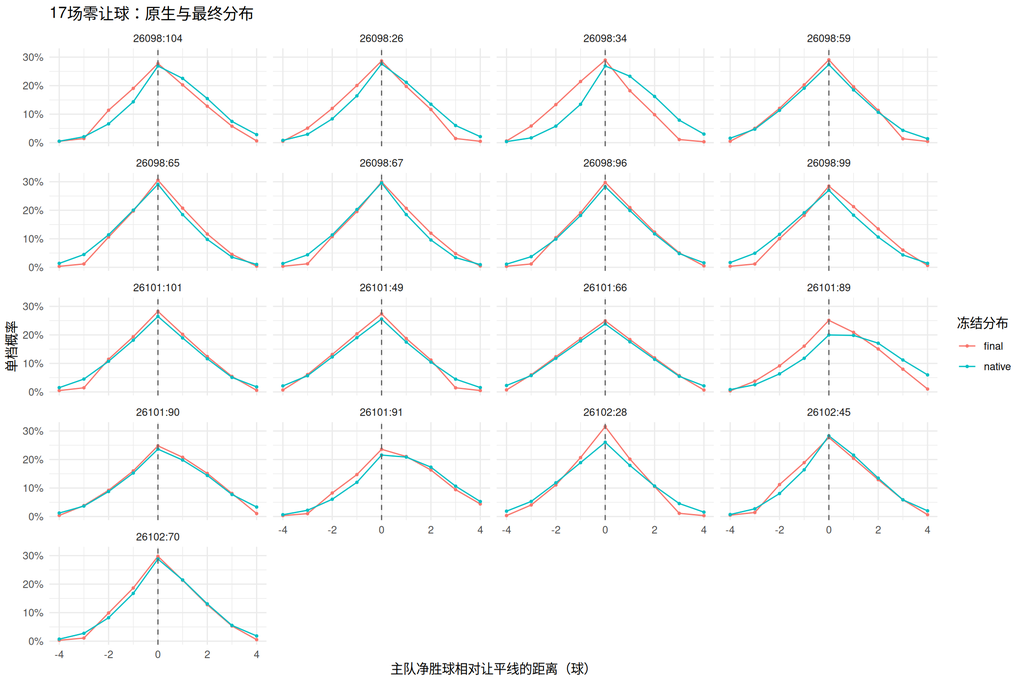

```r
ids0 <- cases$fixture_id[cases$handicap == 0]
margins |> filter(fixture_id %in% ids0, distribution %in% c("native", "final"), between(relative_margin, -4, 4)) |>
  ggplot(aes(relative_margin, probability, colour = distribution)) + geom_line() + geom_point(size = .7) +
  geom_vline(xintercept = 0, linetype = 2, colour = "grey40") + facet_wrap(~fixture_id, ncol = 4) +
  scale_y_continuous(labels = scales::percent) +
  labs(x = "主队净胜球相对让平线的距离（球）", y = "单档概率", colour = "冻结分布",
    title = "17场零让球：原生与最终分布") + theme_minimal()
```

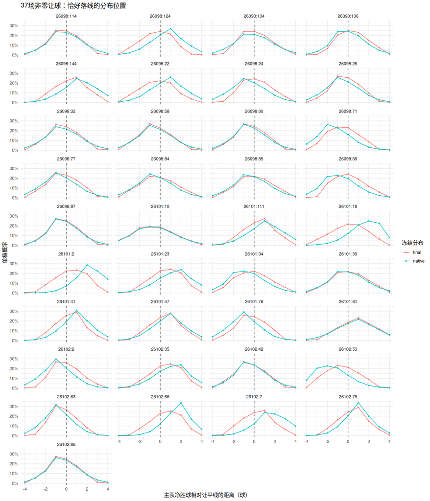

```r
ids1 <- cases$fixture_id[cases$handicap != 0]
margins |> filter(fixture_id %in% ids1, distribution %in% c("native", "final"), between(relative_margin, -4, 4)) |>
  ggplot(aes(relative_margin, probability, colour = distribution)) + geom_line() + geom_point(size = .7) +
  geom_vline(xintercept = 0, linetype = 2, colour = "grey40") + facet_wrap(~fixture_id, ncol = 4) +
  scale_y_continuous(labels = scales::percent) +
  labs(x = "主队净胜球相对让平线的距离（球）", y = "单档概率", colour = "冻结分布",
    title = "37场非零让球：恰好落线的分布位置") + theme_minimal()
```

## 近期攻防与市场：有支持，也有明确缺口

原生λ按已有历史和α构建，近期状态原本已进入λ，不能在本次解释中再叠加一次。54场原生目标线距均值≤0.5球只有24场；最终45场，说明后续市场来源／分布调整在不少比赛上改变了对胜差的判断。原生与最终不是独立证据，市场采用后不能再将同一盘口算作第二份新增支持。

```r
knitr::kable(cases |> select(fixture_id, selected_source, native_home, native_away,
  market_home, market_away, before_expected_margin, before_expected_total,
  native_line_probability, before_line_probability, line_probability, tail_draw_delta),
  digits = 4, caption = "原生、已冻结市场参考、选用来源和尾部后对照；NA不代表反对平局")
```

原生、已冻结市场参考、选用来源和尾部后对照；NA不代表反对平局

| fixture_id | selected_source | native_home | native_away | market_home | market_away | before_expected_margin | before_expected_total | native_line_probability | before_line_probability | line_probability | tail_draw_delta |
| --- | --- | --- | --- | --- | --- | --- | --- | --- | --- | --- | --- |
| 26098:104 | market | 1.6417 | 1.0729 | 1.6017 | 1.5110 | 0.0906 | 3.1127 | 0.2688 | 0.2592 | 0.2774 | 0.0181 |
| 26098:114 | native | 1.9333 | 0.9750 | NA | NA | 0.9583 | 2.9083 | 0.2313 | 0.2313 | 0.2461 | 0.0149 |
| 26098:124 | market | 1.3049 | 1.5701 | 0.8386 | 2.2292 | -1.3905 | 3.0678 | 0.2046 | 0.2273 | 0.2411 | 0.0138 |
| 26098:134 | market | 2.2646 | 1.2812 | 2.0636 | 1.0028 | 1.0608 | 3.0664 | 0.2104 | 0.2269 | 0.2422 | 0.0153 |
| 26098:136 | market | 1.8796 | 0.7867 | 2.1566 | 0.6257 | 1.5309 | 2.7823 | 0.2439 | 0.2379 | 0.2497 | 0.0118 |
| 26098:144 | market | 1.8406 | 1.4421 | 1.3326 | 1.9205 | -0.5879 | 3.2530 | 0.1558 | 0.2097 | 0.2242 | 0.0145 |
| 26098:22 | market | 1.4165 | 1.6568 | 1.0386 | 2.4337 | -1.3951 | 3.4724 | 0.1987 | 0.2131 | 0.2233 | 0.0102 |
| 26098:24 | market | 1.8455 | 1.4241 | 2.1294 | 0.9370 | 1.1924 | 3.0664 | 0.2029 | 0.2278 | 0.2424 | 0.0145 |
| 26098:25 | market | 1.7310 | 1.2664 | 1.7323 | 0.8627 | 0.8697 | 2.5950 | 0.2118 | 0.2421 | 0.2543 | 0.0122 |
| 26098:26 | market | 1.5292 | 1.2042 | 1.4556 | 1.4781 | -0.0225 | 2.9337 | 0.2764 | 0.2690 | 0.2866 | 0.0176 |
| 26098:32 | market | 1.9437 | 1.2312 | 1.8504 | 1.0578 | 0.7927 | 2.9082 | 0.2160 | 0.2272 | 0.2407 | 0.0135 |
| 26098:34 | market | 1.6437 | 0.9833 | 1.2958 | 1.5114 | -0.2155 | 2.8072 | 0.2691 | 0.2744 | 0.2896 | 0.0152 |
| 26098:58 | native | 1.7854 | 1.2646 | 2.5558 | 1.0460 | 0.5208 | 3.0500 | 0.2128 | 0.2128 | 0.2259 | 0.0131 |
| 26098:59 | native | 1.4021 | 1.4458 | NA | NA | -0.0437 | 2.8479 | 0.2738 | 0.2738 | 0.2906 | 0.0168 |
| 26098:60 | market | 1.6687 | 1.0687 | 1.7818 | 1.0005 | 0.7813 | 2.7823 | 0.2261 | 0.2315 | 0.2442 | 0.0127 |
| 26098:65 | market | 1.2312 | 1.3292 | 1.3152 | 1.2535 | 0.0616 | 2.5687 | 0.2912 | 0.2909 | 0.3056 | 0.0147 |
| 26098:67 | market | 1.1917 | 1.2979 | 1.3723 | 1.3017 | 0.0706 | 2.6741 | 0.2959 | 0.2841 | 0.2995 | 0.0154 |
| 26098:71 | market | 1.6956 | 1.0679 | 2.3570 | 0.7327 | 1.6243 | 3.0897 | 0.1594 | 0.2169 | 0.2302 | 0.0134 |
| 26098:77 | market | 1.7021 | 1.3750 | 2.0091 | 1.2213 | 0.7878 | 3.2303 | 0.2032 | 0.2163 | 0.2317 | 0.0154 |
| 26098:84 | market | 1.8795 | 1.3917 | 2.3894 | 1.5810 | 0.8084 | 3.9703 | 0.2055 | 0.1972 | 0.2085 | 0.0113 |
| 26098:85 | market | 1.9875 | 1.2125 | 2.3572 | 1.2525 | 1.1048 | 3.6097 | 0.2169 | 0.2096 | 0.2194 | 0.0099 |
| 26098:89 | market | 2.1143 | 0.9116 | 2.6010 | 0.5116 | 2.0894 | 3.1127 | 0.1972 | 0.2294 | 0.2432 | 0.0138 |
| 26098:96 | native | 1.4042 | 1.2896 | 1.5233 | 1.5431 | 0.1146 | 2.6937 | 0.2825 | 0.2825 | 0.2977 | 0.0151 |
| 26098:97 | market | 1.6227 | 0.8244 | 1.7079 | 0.8871 | 0.8209 | 2.5950 | 0.2462 | 0.2405 | 0.2523 | 0.0118 |
| 26098:99 | market | 1.4229 | 1.4854 | 1.5608 | 1.3474 | 0.2133 | 2.9082 | 0.2703 | 0.2688 | 0.2846 | 0.0159 |
| 26101:10 | native | 2.9423 | 1.5418 | NA | NA | 1.4005 | 4.4841 | 0.1800 | 0.1800 | 0.1876 | 0.0076 |
| 26101:101 | native | 1.5354 | 1.4750 | NA | NA | 0.0604 | 3.0104 | 0.2647 | 0.2647 | 0.2825 | 0.0178 |
| 26101:111 | market | 1.7240 | 1.5466 | 1.1791 | 1.7291 | -0.5499 | 2.9082 | 0.1706 | 0.2183 | 0.2305 | 0.0123 |
| 26101:18 | market | 0.6684 | 1.9228 | 0.2653 | 3.3365 | -3.0712 | 3.6018 | 0.1212 | 0.2097 | 0.2181 | 0.0085 |
| 26101:2 | market | 1.4758 | 1.0471 | 0.8232 | 2.3835 | -1.5602 | 3.2067 | 0.0715 | 0.2113 | 0.2252 | 0.0139 |
| 26101:23 | market | 1.4045 | 1.9464 | 0.7429 | 2.2415 | -1.4986 | 2.9844 | 0.1518 | 0.2140 | 0.2262 | 0.0122 |
| 26101:34 | market | 2.2233 | 0.9395 | 2.7756 | 0.8044 | 1.9712 | 3.5800 | 0.1993 | 0.2132 | 0.2227 | 0.0095 |
| 26101:39 | market | 2.1958 | 1.1854 | 2.4299 | 1.2422 | 1.1877 | 3.6721 | 0.2156 | 0.2080 | 0.2183 | 0.0103 |
| 26101:41 | market | 1.1818 | 1.1250 | 0.8222 | 1.5498 | -0.7277 | 2.3720 | 0.1917 | 0.2466 | 0.2564 | 0.0098 |
| 26101:47 | market | 1.3167 | 1.4562 | 1.1191 | 1.6632 | -0.5441 | 2.7823 | 0.1990 | 0.2220 | 0.2335 | 0.0115 |
| 26101:49 | native | 1.5271 | 1.6542 | NA | NA | -0.1271 | 3.1812 | 0.2555 | 0.2555 | 0.2738 | 0.0183 |
| 26101:66 | native | 1.7695 | 1.7987 | 1.6253 | 1.5108 | -0.0292 | 3.5681 | 0.2384 | 0.2384 | 0.2494 | 0.0110 |
| 26101:76 | market | 1.2854 | 1.2646 | 1.8949 | 1.0133 | 0.8815 | 2.9082 | 0.1946 | 0.2296 | 0.2438 | 0.0142 |
| 26101:81 | native | 1.9854 | 2.1083 | NA | NA | -0.1229 | 4.0937 | 0.1753 | 0.1753 | 0.1860 | 0.0107 |
| 26101:89 | market | 2.4979 | 1.5208 | 1.9212 | 1.4963 | 0.4249 | 3.4175 | 0.1997 | 0.2397 | 0.2510 | 0.0113 |
| 26101:90 | native | 1.9625 | 1.5312 | 1.6408 | 1.8889 | 0.4313 | 3.4937 | 0.2363 | 0.2363 | 0.2480 | 0.0116 |
| 26101:91 | market | 2.2500 | 1.3312 | 2.1456 | 1.5265 | 0.6191 | 3.6721 | 0.2155 | 0.2241 | 0.2358 | 0.0117 |
| 26102:2 | market | 1.3018 | 1.1741 | 1.7284 | 0.7824 | 0.9461 | 2.5108 | 0.2045 | 0.2482 | 0.2604 | 0.0122 |
| 26102:28 | market | 1.5062 | 1.5833 | 1.1940 | 1.2235 | -0.0295 | 2.4176 | 0.2605 | 0.3014 | 0.3154 | 0.0139 |
| 26102:35 | market | 1.1229 | 1.9542 | 0.6950 | 2.1624 | -1.4673 | 2.8574 | 0.1729 | 0.2155 | 0.2267 | 0.0112 |
| 26102:42 | market | 1.6354 | 0.9333 | 1.8301 | 1.1294 | 0.7007 | 2.9595 | 0.2369 | 0.2225 | 0.2357 | 0.0133 |
| 26102:45 | market | 1.4784 | 1.1440 | 1.6116 | 1.5011 | 0.1105 | 3.1127 | 0.2828 | 0.2591 | 0.2771 | 0.0180 |
| 26102:53 | market | 2.2095 | 0.8501 | 3.0539 | 0.4472 | 2.6067 | 3.5012 | 0.1322 | 0.1993 | 0.2134 | 0.0142 |
| 26102:63 | market | 1.1896 | 1.0104 | 1.4993 | 0.8057 | 0.6936 | 2.3050 | 0.2153 | 0.2480 | 0.2664 | 0.0184 |
| 26102:66 | market | 0.8271 | 1.1083 | 0.6255 | 2.1023 | -1.4768 | 2.7278 | 0.1191 | 0.2191 | 0.2295 | 0.0104 |
| 26102:7 | market | 1.9708 | 1.1164 | 1.1331 | 1.9106 | -0.7775 | 3.0437 | 0.1217 | 0.2220 | 0.2363 | 0.0142 |
| 26102:70 | market | 1.4271 | 1.1312 | 1.4225 | 1.2516 | 0.1708 | 2.6741 | 0.2879 | 0.2831 | 0.2976 | 0.0145 |
| 26102:75 | market | 0.9750 | 0.9917 | 0.9770 | 1.5573 | -0.5802 | 2.5343 | 0.2040 | 0.2325 | 0.2425 | 0.0100 |
| 26102:86 | native | 1.7083 | 0.9583 | 1.9962 | 0.9625 | 0.7500 | 2.6667 | 0.2349 | 0.2349 | 0.2467 | 0.0118 |

```r
knitr::kable(cases |> select(fixture_id, matches_home, matches_away,
  long_for_home, recent_for_home, long_against_home, recent_against_home,
  long_for_away, recent_for_away, long_against_away, recent_against_away),
  digits = 3, caption = "逐场近期／长期攻防，单位球／场；原始108行和ESS另见case_forms.csv")
```

逐场近期／长期攻防，单位球／场；原始108行和ESS另见case_forms.csv

| fixture_id | matches_home | matches_away | long_for_home | recent_for_home | long_against_home | recent_against_home | long_for_away | recent_for_away | long_against_away | recent_against_away |
| --- | --- | --- | --- | --- | --- | --- | --- | --- | --- | --- |
| 26098:104 | 30 | 30 | 1.433 | 2.000 | 1.033 | 0.750 | 1.633 | 0.875 | 1.633 | 1.500 |
| 26098:114 | 30 | 30 | 2.200 | 1.375 | 0.767 | 0.750 | 1.133 | 1.250 | 2.033 | 2.125 |
| 26098:124 | 33 | 33 | 1.939 | 1.250 | 1.121 | 1.250 | 1.909 | 2.000 | 1.030 | 1.000 |
| 26098:134 | 30 | 30 | 1.933 | 2.750 | 1.500 | 1.125 | 1.500 | 1.000 | 2.000 | 2.375 |
| 26098:136 | 45 | 38 | 2.400 | 2.125 | 0.667 | 0.750 | 1.105 | 0.625 | 1.368 | 1.625 |
| 26098:144 | 35 | 33 | 2.457 | 3.125 | 0.886 | 0.750 | 1.758 | 2.375 | 1.030 | 0.750 |
| 26098:22 | 35 | 34 | 1.857 | 2.000 | 1.171 | 1.375 | 1.706 | 2.375 | 1.059 | 0.750 |
| 26098:24 | 35 | 35 | 2.000 | 2.500 | 1.114 | 1.625 | 1.457 | 1.500 | 1.257 | 1.625 |
| 26098:25 | 36 | 35 | 1.417 | 1.750 | 1.333 | 1.500 | 0.857 | 1.375 | 2.257 | 1.500 |
| 26098:26 | 30 | 30 | 1.500 | 1.625 | 1.267 | 1.000 | 1.300 | 1.250 | 1.367 | 1.625 |
| 26098:32 | 30 | 30 | 1.300 | 1.125 | 1.400 | 1.375 | 0.900 | 1.250 | 2.100 | 3.250 |
| 26098:34 | 30 | 30 | 1.700 | 1.500 | 1.000 | 0.875 | 0.933 | 1.125 | 2.000 | 1.375 |
| 26098:58 | 30 | 30 | 1.867 | 2.625 | 1.233 | 1.375 | 1.200 | 1.250 | 1.400 | 1.250 |
| 26098:59 | 30 | 30 | 2.100 | 1.875 | 1.133 | 1.750 | 1.400 | 1.500 | 1.133 | 0.500 |
| 26098:60 | 30 | 30 | 1.600 | 2.000 | 1.400 | 1.125 | 1.000 | 0.750 | 1.700 | 1.375 |
| 26098:65 | 30 | 30 | 1.067 | 1.250 | 1.267 | 1.125 | 1.300 | 1.625 | 1.233 | 1.375 |
| 26098:67 | 30 | 30 | 1.067 | 1.625 | 1.567 | 0.875 | 1.500 | 1.250 | 1.200 | 0.875 |
| 26098:71 | 31 | 30 | 2.032 | 1.875 | 1.097 | 0.500 | 1.300 | 1.375 | 1.500 | 1.375 |
| 26098:77 | 30 | 30 | 1.700 | 1.250 | 1.633 | 1.500 | 1.367 | 1.000 | 1.733 | 2.125 |
| 26098:84 | 35 | 30 | 1.943 | 1.750 | 1.200 | 1.250 | 1.367 | 1.750 | 1.700 | 2.125 |
| 26098:85 | 30 | 30 | 1.933 | 2.125 | 1.500 | 1.250 | 1.100 | 1.000 | 1.767 | 2.125 |
| 26098:89 | 35 | 35 | 1.543 | 1.750 | 1.000 | 1.000 | 0.771 | 0.875 | 1.914 | 3.250 |
| 26098:96 | 30 | 30 | 1.833 | 1.625 | 1.100 | 1.500 | 1.433 | 1.125 | 1.033 | 1.125 |
| 26098:97 | 32 | 34 | 1.594 | 1.625 | 0.938 | 0.875 | 0.735 | 0.750 | 1.647 | 1.625 |
| 26098:99 | 30 | 30 | 1.767 | 1.375 | 1.633 | 1.750 | 1.433 | 1.125 | 1.300 | 1.250 |
| 26101:10 | 31 | 32 | 3.613 | 4.125 | 0.355 | 0.125 | 2.188 | 3.500 | 1.906 | 2.125 |
| 26101:101 | 30 | 30 | 1.767 | 1.500 | 1.067 | 1.250 | 1.833 | 1.750 | 1.500 | 1.375 |
| 26101:111 | 34 | 35 | 1.735 | 2.250 | 1.029 | 1.250 | 1.657 | 2.250 | 1.286 | 1.625 |
| 26101:18 | 35 | 34 | 0.343 | 0.375 | 2.743 | 3.375 | 0.824 | 0.750 | 1.206 | 0.750 |
| 26101:2 | 33 | 31 | 2.061 | 1.625 | 0.515 | 0.500 | 1.548 | 1.625 | 0.968 | 1.250 |
| 26101:23 | 35 | 35 | 2.086 | 2.000 | 0.971 | 1.375 | 2.314 | 3.125 | 0.657 | 0.875 |
| 26101:34 | 37 | 36 | 2.351 | 3.250 | 1.216 | 0.625 | 1.167 | 0.750 | 1.417 | 1.875 |
| 26101:39 | 30 | 30 | 1.967 | 1.500 | 1.233 | 1.125 | 1.133 | 1.250 | 2.567 | 2.750 |
| 26101:41 | 36 | 33 | 0.833 | 0.500 | 1.250 | 1.250 | 1.000 | 1.000 | 1.394 | 2.000 |
| 26101:47 | 30 | 30 | 1.100 | 0.250 | 1.433 | 1.875 | 1.267 | 1.250 | 2.167 | 1.750 |
| 26101:49 | 30 | 30 | 1.200 | 1.250 | 1.400 | 1.500 | 1.467 | 2.250 | 2.033 | 1.625 |
| 26101:66 | 30 | 34 | 2.100 | 1.500 | 1.467 | 2.125 | 1.853 | 1.750 | 1.853 | 1.625 |
| 26101:76 | 30 | 30 | 1.633 | 1.375 | 1.233 | 1.125 | 1.200 | 1.500 | 1.133 | 1.000 |
| 26101:81 | 30 | 30 | 1.600 | 2.250 | 1.600 | 1.875 | 1.833 | 3.125 | 1.967 | 2.125 |
| 26101:89 | 30 | 30 | 2.033 | 2.375 | 1.533 | 1.500 | 1.300 | 1.750 | 2.333 | 3.250 |
| 26101:90 | 30 | 30 | 1.667 | 1.625 | 1.633 | 1.500 | 1.867 | 1.125 | 1.933 | 2.625 |
| 26101:91 | 30 | 30 | 1.900 | 2.125 | 1.667 | 1.625 | 1.033 | 1.000 | 2.100 | 2.875 |
| 26102:2 | 35 | 35 | 0.886 | 1.625 | 1.600 | 1.625 | 0.971 | 0.500 | 1.571 | 1.125 |
| 26102:28 | 30 | 30 | 2.133 | 1.875 | 1.133 | 1.375 | 1.700 | 2.125 | 1.267 | 0.750 |
| 26102:35 | 30 | 30 | 1.000 | 0.875 | 2.233 | 2.750 | 1.333 | 1.500 | 1.367 | 1.250 |
| 26102:42 | 30 | 30 | 1.900 | 1.500 | 0.833 | 1.000 | 0.900 | 1.000 | 1.767 | 1.375 |
| 26102:45 | 31 | 30 | 1.839 | 1.625 | 1.226 | 1.250 | 1.100 | 1.000 | 1.200 | 1.250 |
| 26102:53 | 35 | 36 | 2.171 | 2.625 | 0.914 | 1.125 | 1.111 | 0.250 | 1.667 | 2.375 |
| 26102:63 | 30 | 30 | 1.267 | 1.000 | 0.867 | 0.750 | 1.300 | 1.125 | 1.367 | 1.125 |
| 26102:66 | 30 | 30 | 0.867 | 0.625 | 1.067 | 1.500 | 0.867 | 1.000 | 1.067 | 0.750 |
| 26102:7 | 36 | 35 | 1.583 | 2.000 | 0.833 | 1.375 | 1.257 | 1.000 | 1.800 | 2.500 |
| 26102:70 | 30 | 30 | 1.533 | 1.125 | 1.167 | 1.375 | 1.233 | 0.750 | 1.300 | 1.750 |
| 26102:75 | 30 | 30 | 1.133 | 1.000 | 1.167 | 1.125 | 0.800 | 0.875 | 0.767 | 1.000 |
| 26102:86 | 30 | 30 | 1.767 | 1.875 | 0.567 | 0.500 | 1.267 | 1.500 | 1.567 | 1.625 |

```r
knitr::kable(read_csv(file.path(out, "asian_alignment.csv"), show_col_types = FALSE), digits = 3,
  caption = "48场有冻结亚盘，均在目标线半球内；缺6场保持未知")
```

48场有冻结亚盘，均在目标线半球内；缺6场保持未知

| fixture_id | company_id | quote_at | asian_handicap | home_decimal | away_decimal | target_margin | line_minus_asian_center |
| --- | --- | --- | --- | --- | --- | --- | --- |
| 26098:104 | 8 | 2026-09-24 12:20:32 | 0.00 | 1.80 | 2.00 | 0 | 0.00 |
| 26098:124 | 8 | 2026-09-26 10:22:32 | 1.25 | 2.00 | 1.85 | -1 | 0.25 |
| 26098:134 | 8 | 2026-09-26 07:43:31 | -1.00 | 1.90 | 1.90 | 1 | 0.00 |
| 26098:136 | 8 | 2026-09-27 08:19:34 | -1.50 | 1.95 | 1.85 | 1 | -0.50 |
| 26098:144 | 8 | 2026-09-27 10:32:22 | 0.50 | 1.95 | 1.90 | -1 | -0.50 |
| 26098:22 | 8 | 2026-09-24 16:34:59 | 1.25 | 2.00 | 1.85 | -1 | 0.25 |
| 26098:24 | 8 | 2026-09-24 13:32:08 | -1.25 | 2.03 | 1.78 | 1 | -0.25 |
| 26098:25 | 8 | 2026-09-24 17:58:38 | -0.75 | 1.83 | 1.98 | 1 | 0.25 |
| 26098:26 | 8 | 2026-09-24 09:05:24 | 0.00 | 1.93 | 1.88 | 0 | 0.00 |
| 26098:32 | 8 | 2026-09-24 09:31:48 | -0.75 | 1.90 | 1.90 | 1 | 0.25 |
| 26098:34 | 8 | 2026-09-24 12:53:28 | 0.25 | 1.88 | 1.93 | 0 | 0.25 |
| 26098:58 | 8 | 2026-09-25 09:05:22 | -1.50 | 1.98 | 1.88 | 1 | -0.50 |
| 26098:60 | 8 | 2026-09-24 10:10:59 | -0.75 | 1.95 | 1.90 | 1 | 0.25 |
| 26098:65 | 8 | 2026-09-25 10:41:44 | 0.00 | 1.83 | 2.03 | 0 | 0.00 |
| 26098:67 | 8 | 2026-09-23 20:09:53 | 0.00 | 1.83 | 2.03 | 0 | 0.00 |
| 26098:71 | 8 | 2026-09-25 14:13:46 | -1.50 | 1.85 | 1.95 | 2 | 0.50 |
| 26098:77 | 8 | 2026-09-25 07:17:50 | -0.75 | 1.90 | 1.90 | 1 | 0.25 |
| 26098:84 | 8 | 2026-09-24 06:56:18 | -0.75 | 1.88 | 1.93 | 1 | 0.25 |
| 26098:85 | 8 | 2026-09-25 09:40:34 | -1.00 | 1.85 | 1.95 | 1 | 0.00 |
| 26098:89 | 8 | 2026-09-25 12:30:46 | -2.00 | 1.90 | 1.90 | 2 | 0.00 |
| 26098:96 | 8 | 2026-09-25 13:43:28 | 0.00 | 1.93 | 1.88 | 0 | 0.00 |
| 26098:97 | 8 | 2026-09-25 12:40:18 | -0.75 | 1.90 | 1.90 | 1 | 0.25 |
| 26098:99 | 8 | 2026-09-25 12:12:09 | -0.25 | 1.98 | 1.83 | 0 | -0.25 |
| 26101:111 | 8 | 2026-10-03 18:43:36 | 0.50 | 1.90 | 1.95 | -1 | -0.50 |
| 26101:18 | 8 | 2026-09-28 18:40:32 | 3.00 | 1.85 | 1.95 | -3 | 0.00 |
| 26101:2 | 8 | 2026-09-28 06:51:49 | 1.50 | 1.90 | 1.90 | -2 | -0.50 |
| 26101:23 | 8 | 2026-09-28 14:18:48 | 1.50 | 1.85 | 2.00 | -2 | -0.50 |
| 26101:34 | 8 | 2026-09-30 16:24:07 | -2.00 | 2.03 | 1.83 | 2 | 0.00 |
| 26101:39 | 8 | 2026-09-30 21:12:20 | -1.00 | 1.78 | 2.03 | 1 | 0.00 |
| 26101:41 | 8 | 2026-10-01 11:29:02 | 0.50 | 2.03 | 1.78 | -1 | -0.50 |
| 26101:47 | 8 | 2026-09-30 19:10:07 | 0.50 | 1.88 | 1.93 | -1 | -0.50 |
| 26101:66 | 8 | 2026-10-02 05:14:27 | 0.00 | 1.78 | 2.03 | 0 | 0.00 |
| 26101:76 | 8 | 2026-10-01 06:30:03 | -0.75 | 1.85 | 2.00 | 1 | 0.25 |
| 26101:89 | 8 | 2026-10-02 12:04:30 | -0.50 | 2.00 | 1.80 | 0 | -0.50 |
| 26101:90 | 8 | 2026-09-30 18:05:26 | 0.25 | 1.85 | 1.95 | 0 | 0.25 |
| 26101:91 | 8 | 2026-10-02 12:12:08 | -0.50 | 1.85 | 1.95 | 0 | -0.50 |
| 26102:2 | 8 | 2026-10-04 15:39:55 | -0.75 | 1.78 | 2.03 | 1 | 0.25 |
| 26102:28 | 8 | 2026-10-05 15:13:12 | 0.00 | 1.95 | 1.85 | 0 | 0.00 |
| 26102:35 | 8 | 2026-10-05 13:53:35 | 1.50 | 1.80 | 2.00 | -2 | -0.50 |
| 26102:42 | 8 | 2026-10-05 15:51:16 | -0.75 | 2.00 | 1.80 | 1 | 0.25 |
| 26102:45 | 8 | 2026-10-05 07:03:24 | 0.00 | 1.78 | 2.03 | 0 | 0.00 |
| 26102:53 | 8 | 2026-10-05 14:55:45 | -2.50 | 1.90 | 1.90 | 3 | 0.50 |
| 26102:63 | 8 | 2026-10-05 23:25:21 | -0.50 | 1.80 | 2.00 | 1 | 0.50 |
| 26102:66 | 8 | 2026-10-05 19:50:22 | 1.50 | 1.80 | 2.00 | -2 | -0.50 |
| 26102:7 | 8 | 2026-10-04 15:43:03 | 0.75 | 1.88 | 1.93 | -1 | -0.25 |
| 26102:70 | 8 | 2026-10-06 21:04:09 | -0.25 | 2.10 | 1.78 | 0 | -0.25 |
| 26102:75 | 8 | 2026-10-06 17:53:30 | 0.50 | 1.90 | 1.90 | -1 | -0.50 |
| 26102:86 | 8 | 2026-10-07 22:54:58 | -1.00 | 1.98 | 1.88 | 1 | 0.00 |

```r
knitr::kable(read_csv(file.path(out, "asian_controls.csv"), show_col_types = FALSE), digits = 4,
  caption = "完整197场的亚盘位置对照，不能只用命中54场证明盘口支持有效")
```

完整197场的亚盘位置对照，不能只用命中54场证明盘口支持有效

| ah_alignment | n | missed_draws | draw_rate |
| --- | --- | --- | --- |
| missing | 29 | 6 | 0.2069 |
| outside_half_goal | 2 | 0 | 0.0000 |
| within_half_goal | 166 | 48 | 0.2892 |

54场43场最终选用市场、11场保留原生。48场有冻结亚盘，其隐含净胜中线与北单让平目标相距≤0.5球；这支持“赢多少球的量级相近”，不能推出恰好到线比两侧总质量更大，也未必支持改掉Top2。

54场冻结文章事实均为空（整个345场账本有10条，均在其他比赛）。所以没有据此完成阵容、伤停、战意、排名和对手等级的独立核验；不能说海外主力回归、保级或轮换等理由已得到支持。当前“基本面”证据主要是主客历史进失球和近期趋势，缺少的定性维度如实保留。本轮不以当前新闻回填历史赛前信息。

## 对照：中心支持没有变成清晰的选择优势

```r
knitr::kable(controls, digits = 4,
  caption = "全部197场最终让平第三：54发生／143未发生；预设几何与基本面分组")
```

全部197场最终让平第三：54发生／143未发生；预设几何与基本面分组

| dimension | stratum | n | missed_draws | draw_rate | mean_draw_probability |
| --- | --- | --- | --- | --- | --- |
| draw_type | actual_draw_h0 | 63 | 17 | 0.2698 | 0.2794 |
| draw_type | exact_handicap_nonzero | 134 | 37 | 0.2761 | 0.2366 |
| event_type | cup | 11 | 2 | 0.1818 | 0.2505 |
| event_type | league | 99 | 31 | 0.3131 | 0.2568 |
| event_type | national | 53 | 18 | 0.3396 | 0.2438 |
| event_type | youth | 34 | 3 | 0.0882 | 0.2413 |
| selected_source | market | 150 | 43 | 0.2867 | 0.2493 |
| selected_source | native | 47 | 11 | 0.2340 | 0.2535 |
| line_is_mode | FALSE | 80 | 27 | 0.3375 | 0.2373 |
| line_is_mode | TRUE | 117 | 27 | 0.2308 | 0.2591 |
| margin_top2 | TRUE | 197 | 54 | 0.2741 | 0.2503 |
| within_half_goal_mean | FALSE | 22 | 9 | 0.4091 | 0.2209 |
| within_half_goal_mean | TRUE | 175 | 45 | 0.2571 | 0.2540 |
| native_within_half_goal_mean | FALSE | 92 | 30 | 0.3261 | 0.2370 |
| native_within_half_goal_mean | TRUE | 105 | 24 | 0.2286 | 0.2619 |
| total_band | [2,2.5) | 15 | 3 | 0.2000 | 0.2770 |
| total_band | [2.5,3) | 86 | 24 | 0.2791 | 0.2613 |
| total_band | [3,Inf) | 96 | 27 | 0.2812 | 0.2362 |
| second_gap_band | [0,0.02) | 46 | 14 | 0.3043 | 0.2698 |
| second_gap_band | [0.02,0.05) | 65 | 21 | 0.3231 | 0.2541 |
| second_gap_band | [0.05,0.1) | 44 | 9 | 0.2045 | 0.2393 |
| second_gap_band | [0.1,Inf) | 42 | 10 | 0.2381 | 0.2345 |

197场让平第三全部都是净胜球单档前二。因此54场的这个共性无法筛出它们。117场让平线为众数，其中27场发生（23.1%）；80场不是众数，其中27场发生（33.8%）。不能把众数资格直接当成提升让平排序的证据。

零让球对照63场，平均平局预测27.9%、实际发生17/63=27.0%，并没有显示这一子组整体低估。非零134场，平均让平预测23.7%、实际37/134=27.6%，约低估3.9个百分点，有研究价值但不支持全体硬性上调。第二名差距不足5个百分点的111场出现35次（31.5%），其余86场19次（22.1%）；这是探索性差异，尚未在新期检验，不据此形成新保护门槛。

## 54场逐场解释与代表案例

```r
knitr::kable(review |> select(fixture_id, structure_note, fundamental_note, market_note,
  conclusion, qualitative_gap), caption = "逐场证据说明；为字段驱动的可复现解释，不冒充独立人工定性裁决")
```

逐场证据说明；为字段驱动的可复现解释，不冒充独立人工定性裁决

| fixture_id | structure_note | fundamental_note | market_note | conclusion | qualitative_gap |
| --- | --- | --- | --- | --- | --- |
| 26098:104 | 让平对应净胜球为众数；单档中心支持保留，但不证明应高于左右整类 | 原生λ主/客 1.64/1.07；目标净胜球-0，距原生均值-0.57；近期/长期主进球 2.00/1.43，客进球 0.88/1.63 | 亚盘主-0.00，对应净胜中线+0.00；目标距该线-0.00球 | 支持将让平保留为可讨论场景；是否取代第二名仍未证明 | 本场冻结文章事实为空；阵容、伤停、战意及独立排名未完成逐场核验 |
| 26098:114 | 让平对应净胜球为第二档；靠近中心，仍需比较整类与盘口 | 原生λ主/客 1.93/0.97；目标净胜球+1，距原生均值+0.04；近期/长期主进球 1.38/2.20，客进球 1.25/1.13 | 冻结亚盘缺失，不能作盘口支持判断 | 支持将让平保留为可讨论场景；是否取代第二名仍未证明 | 本场冻结文章事实为空；阵容、伤停、战意及独立排名未完成逐场核验 |
| 26098:124 | 让平对应净胜球为众数；单档中心支持保留，但不证明应高于左右整类 | 原生λ主/客 1.30/1.57；目标净胜球-1，距原生均值-0.73；近期/长期主进球 1.25/1.94，客进球 2.00/1.91 | 亚盘主+1.25，对应净胜中线-1.25；目标距该线+0.25球 | 支持将让平保留为可讨论场景；是否取代第二名仍未证明 | 本场冻结文章事实为空；阵容、伤停、战意及独立排名未完成逐场核验 |
| 26098:134 | 让平对应净胜球为众数；单档中心支持保留，但不证明应高于左右整类 | 原生λ主/客 2.26/1.28；目标净胜球+1，距原生均值+0.02；近期/长期主进球 2.75/1.93，客进球 1.00/1.50 | 亚盘主-1.00，对应净胜中线+1.00；目标距该线+0.00球 | 支持将让平保留为可讨论场景；是否取代第二名仍未证明 | 本场冻结文章事实为空；阵容、伤停、战意及独立排名未完成逐场核验 |
| 26098:136 | 让平对应净胜球为众数；单档中心支持保留，但不证明应高于左右整类 | 原生λ主/客 1.88/0.79；目标净胜球+1，距原生均值-0.09；近期/长期主进球 2.12/2.40，客进球 0.62/1.11 | 亚盘主-1.50，对应净胜中线+1.50；目标距该线-0.50球 | 支持将让平保留为可讨论场景；是否取代第二名仍未证明 | 本场冻结文章事实为空；阵容、伤停、战意及独立排名未完成逐场核验 |
| 26098:144 | 让平对应净胜球为第二档；靠近中心，仍需比较整类与盘口 | 原生λ主/客 1.84/1.44；目标净胜球-1，距原生均值-1.40；近期/长期主进球 3.12/2.46，客进球 2.38/1.76 | 亚盘主+0.50，对应净胜中线-0.50；目标距该线-0.50球 | 支持将让平保留为可讨论场景；是否取代第二名仍未证明 | 本场冻结文章事实为空；阵容、伤停、战意及独立排名未完成逐场核验 |
| 26098:22 | 让平对应净胜球为众数；单档中心支持保留，但不证明应高于左右整类 | 原生λ主/客 1.42/1.66；目标净胜球-1，距原生均值-0.76；近期/长期主进球 2.00/1.86，客进球 2.38/1.71 | 亚盘主+1.25，对应净胜中线-1.25；目标距该线+0.25球 | 支持将让平保留为可讨论场景；是否取代第二名仍未证明 | 本场冻结文章事实为空；阵容、伤停、战意及独立排名未完成逐场核验 |
| 26098:24 | 让平对应净胜球为众数；单档中心支持保留，但不证明应高于左右整类 | 原生λ主/客 1.85/1.42；目标净胜球+1，距原生均值+0.58；近期/长期主进球 2.50/2.00，客进球 1.50/1.46 | 亚盘主-1.25，对应净胜中线+1.25；目标距该线-0.25球 | 支持将让平保留为可讨论场景；是否取代第二名仍未证明 | 本场冻结文章事实为空；阵容、伤停、战意及独立排名未完成逐场核验 |
| 26098:25 | 让平对应净胜球为第二档；靠近中心，仍需比较整类与盘口 | 原生λ主/客 1.73/1.27；目标净胜球+1，距原生均值+0.54；近期/长期主进球 1.75/1.42，客进球 1.38/0.86 | 亚盘主-0.75，对应净胜中线+0.75；目标距该线+0.25球 | 支持将让平保留为可讨论场景；是否取代第二名仍未证明 | 本场冻结文章事实为空；阵容、伤停、战意及独立排名未完成逐场核验 |
| 26098:26 | 让平对应净胜球为众数；单档中心支持保留，但不证明应高于左右整类 | 原生λ主/客 1.53/1.20；目标净胜球-0，距原生均值-0.32；近期/长期主进球 1.62/1.50，客进球 1.25/1.30 | 亚盘主-0.00，对应净胜中线+0.00；目标距该线-0.00球 | 支持将让平保留为可讨论场景；是否取代第二名仍未证明 | 本场冻结文章事实为空；阵容、伤停、战意及独立排名未完成逐场核验 |
| 26098:32 | 让平对应净胜球为第二档；靠近中心，仍需比较整类与盘口 | 原生λ主/客 1.94/1.23；目标净胜球+1，距原生均值+0.29；近期/长期主进球 1.12/1.30，客进球 1.25/0.90 | 亚盘主-0.75，对应净胜中线+0.75；目标距该线+0.25球 | 支持将让平保留为可讨论场景；是否取代第二名仍未证明 | 本场冻结文章事实为空；阵容、伤停、战意及独立排名未完成逐场核验 |
| 26098:34 | 让平对应净胜球为众数；单档中心支持保留，但不证明应高于左右整类 | 原生λ主/客 1.64/0.98；目标净胜球-0，距原生均值-0.66；近期/长期主进球 1.50/1.70，客进球 1.12/0.93 | 亚盘主+0.25，对应净胜中线-0.25；目标距该线+0.25球 | 支持将让平保留为可讨论场景；是否取代第二名仍未证明 | 本场冻结文章事实为空；阵容、伤停、战意及独立排名未完成逐场核验 |
| 26098:58 | 让平对应净胜球为第二档；靠近中心，仍需比较整类与盘口 | 原生λ主/客 1.79/1.26；目标净胜球+1，距原生均值+0.48；近期/长期主进球 2.62/1.87，客进球 1.25/1.20 | 亚盘主-1.50，对应净胜中线+1.50；目标距该线-0.50球 | 支持将让平保留为可讨论场景；是否取代第二名仍未证明 | 本场冻结文章事实为空；阵容、伤停、战意及独立排名未完成逐场核验 |
| 26098:59 | 让平对应净胜球为众数；单档中心支持保留，但不证明应高于左右整类 | 原生λ主/客 1.40/1.45；目标净胜球-0，距原生均值+0.04；近期/长期主进球 1.88/2.10，客进球 1.50/1.40 | 冻结亚盘缺失，不能作盘口支持判断 | 支持将让平保留为可讨论场景；是否取代第二名仍未证明 | 本场冻结文章事实为空；阵容、伤停、战意及独立排名未完成逐场核验 |
| 26098:60 | 让平对应净胜球为第二档；靠近中心，仍需比较整类与盘口 | 原生λ主/客 1.67/1.07；目标净胜球+1，距原生均值+0.40；近期/长期主进球 2.00/1.60，客进球 0.75/1.00 | 亚盘主-0.75，对应净胜中线+0.75；目标距该线+0.25球 | 支持将让平保留为可讨论场景；是否取代第二名仍未证明 | 本场冻结文章事实为空；阵容、伤停、战意及独立排名未完成逐场核验 |
| 26098:65 | 让平对应净胜球为众数；单档中心支持保留，但不证明应高于左右整类 | 原生λ主/客 1.23/1.33；目标净胜球-0，距原生均值+0.10；近期/长期主进球 1.25/1.07，客进球 1.62/1.30 | 亚盘主-0.00，对应净胜中线+0.00；目标距该线-0.00球 | 支持将让平保留为可讨论场景；是否取代第二名仍未证明 | 本场冻结文章事实为空；阵容、伤停、战意及独立排名未完成逐场核验 |
| 26098:67 | 让平对应净胜球为众数；单档中心支持保留，但不证明应高于左右整类 | 原生λ主/客 1.19/1.30；目标净胜球-0，距原生均值+0.11；近期/长期主进球 1.62/1.07，客进球 1.25/1.50 | 亚盘主-0.00，对应净胜中线+0.00；目标距该线-0.00球 | 支持将让平保留为可讨论场景；是否取代第二名仍未证明 | 本场冻结文章事实为空；阵容、伤停、战意及独立排名未完成逐场核验 |
| 26098:71 | 让平对应净胜球为第二档；靠近中心，仍需比较整类与盘口 | 原生λ主/客 1.70/1.07；目标净胜球+2，距原生均值+1.37；近期/长期主进球 1.88/2.03，客进球 1.38/1.30 | 亚盘主-1.50，对应净胜中线+1.50；目标距该线+0.50球 | 支持将让平保留为可讨论场景；是否取代第二名仍未证明 | 本场冻结文章事实为空；阵容、伤停、战意及独立排名未完成逐场核验 |
| 26098:77 | 让平对应净胜球为第二档；靠近中心，仍需比较整类与盘口 | 原生λ主/客 1.70/1.37；目标净胜球+1，距原生均值+0.67；近期/长期主进球 1.25/1.70，客进球 1.00/1.37 | 亚盘主-0.75，对应净胜中线+0.75；目标距该线+0.25球 | 支持将让平保留为可讨论场景；是否取代第二名仍未证明 | 本场冻结文章事实为空；阵容、伤停、战意及独立排名未完成逐场核验 |
| 26098:84 | 让平对应净胜球为第二档；靠近中心，仍需比较整类与盘口 | 原生λ主/客 1.88/1.39；目标净胜球+1，距原生均值+0.51；近期/长期主进球 1.75/1.94，客进球 1.75/1.37 | 亚盘主-0.75，对应净胜中线+0.75；目标距该线+0.25球 | 支持将让平保留为可讨论场景；是否取代第二名仍未证明 | 本场冻结文章事实为空；阵容、伤停、战意及独立排名未完成逐场核验 |
| 26098:85 | 让平对应净胜球为众数；单档中心支持保留，但不证明应高于左右整类 | 原生λ主/客 1.99/1.21；目标净胜球+1，距原生均值+0.23；近期/长期主进球 2.12/1.93，客进球 1.00/1.10 | 亚盘主-1.00，对应净胜中线+1.00；目标距该线+0.00球 | 支持将让平保留为可讨论场景；是否取代第二名仍未证明 | 本场冻结文章事实为空；阵容、伤停、战意及独立排名未完成逐场核验 |
| 26098:89 | 让平对应净胜球为众数；单档中心支持保留，但不证明应高于左右整类 | 原生λ主/客 2.11/0.91；目标净胜球+2，距原生均值+0.80；近期/长期主进球 1.75/1.54，客进球 0.88/0.77 | 亚盘主-2.00，对应净胜中线+2.00；目标距该线+0.00球 | 支持将让平保留为可讨论场景；是否取代第二名仍未证明 | 本场冻结文章事实为空；阵容、伤停、战意及独立排名未完成逐场核验 |
| 26098:96 | 让平对应净胜球为众数；单档中心支持保留，但不证明应高于左右整类 | 原生λ主/客 1.40/1.29；目标净胜球-0，距原生均值-0.11；近期/长期主进球 1.62/1.83，客进球 1.12/1.43 | 亚盘主-0.00，对应净胜中线+0.00；目标距该线-0.00球 | 支持将让平保留为可讨论场景；是否取代第二名仍未证明 | 本场冻结文章事实为空；阵容、伤停、战意及独立排名未完成逐场核验 |
| 26098:97 | 让平对应净胜球为第二档；靠近中心，仍需比较整类与盘口 | 原生λ主/客 1.62/0.82；目标净胜球+1，距原生均值+0.20；近期/长期主进球 1.62/1.59，客进球 0.75/0.74 | 亚盘主-0.75，对应净胜中线+0.75；目标距该线+0.25球 | 支持将让平保留为可讨论场景；是否取代第二名仍未证明 | 本场冻结文章事实为空；阵容、伤停、战意及独立排名未完成逐场核验 |
| 26098:99 | 让平对应净胜球为众数；单档中心支持保留，但不证明应高于左右整类 | 原生λ主/客 1.42/1.49；目标净胜球-0，距原生均值+0.06；近期/长期主进球 1.38/1.77，客进球 1.12/1.43 | 亚盘主-0.25，对应净胜中线+0.25；目标距该线-0.25球 | 支持将让平保留为可讨论场景；是否取代第二名仍未证明 | 本场冻结文章事实为空；阵容、伤停、战意及独立排名未完成逐场核验 |
| 26101:10 | 让平对应净胜球为第二档；靠近中心，仍需比较整类与盘口 | 原生λ主/客 2.94/1.54；目标净胜球+2，距原生均值+0.60；近期/长期主进球 4.12/3.61，客进球 3.50/2.19 | 冻结亚盘缺失，不能作盘口支持判断 | 支持将让平保留为可讨论场景；是否取代第二名仍未证明 | 本场冻结文章事实为空；阵容、伤停、战意及独立排名未完成逐场核验 |
| 26101:101 | 让平对应净胜球为众数；单档中心支持保留，但不证明应高于左右整类 | 原生λ主/客 1.54/1.47；目标净胜球-0，距原生均值-0.06；近期/长期主进球 1.50/1.77，客进球 1.75/1.83 | 冻结亚盘缺失，不能作盘口支持判断 | 支持将让平保留为可讨论场景；是否取代第二名仍未证明 | 本场冻结文章事实为空；阵容、伤停、战意及独立排名未完成逐场核验 |
| 26101:111 | 让平对应净胜球为第二档；靠近中心，仍需比较整类与盘口 | 原生λ主/客 1.72/1.55；目标净胜球-1，距原生均值-1.18；近期/长期主进球 2.25/1.74，客进球 2.25/1.66 | 亚盘主+0.50，对应净胜中线-0.50；目标距该线-0.50球 | 支持将让平保留为可讨论场景；是否取代第二名仍未证明 | 本场冻结文章事实为空；阵容、伤停、战意及独立排名未完成逐场核验 |
| 26101:18 | 让平对应净胜球为众数；单档中心支持保留，但不证明应高于左右整类 | 原生λ主/客 0.67/1.92；目标净胜球-3，距原生均值-1.75；近期/长期主进球 0.38/0.34，客进球 0.75/0.82 | 亚盘主+3.00，对应净胜中线-3.00；目标距该线+0.00球 | 支持将让平保留为可讨论场景；是否取代第二名仍未证明 | 本场冻结文章事实为空；阵容、伤停、战意及独立排名未完成逐场核验 |
| 26101:2 | 让平对应净胜球为第二档；靠近中心，仍需比较整类与盘口 | 原生λ主/客 1.48/1.05；目标净胜球-2，距原生均值-2.43；近期/长期主进球 1.62/2.06，客进球 1.62/1.55 | 亚盘主+1.50，对应净胜中线-1.50；目标距该线-0.50球 | 支持将让平保留为可讨论场景；是否取代第二名仍未证明 | 本场冻结文章事实为空；阵容、伤停、战意及独立排名未完成逐场核验 |
| 26101:23 | 让平对应净胜球为第二档；靠近中心，仍需比较整类与盘口 | 原生λ主/客 1.40/1.95；目标净胜球-2，距原生均值-1.46；近期/长期主进球 2.00/2.09，客进球 3.12/2.31 | 亚盘主+1.50，对应净胜中线-1.50；目标距该线-0.50球 | 支持将让平保留为可讨论场景；是否取代第二名仍未证明 | 本场冻结文章事实为空；阵容、伤停、战意及独立排名未完成逐场核验 |
| 26101:34 | 让平对应净胜球为众数；单档中心支持保留，但不证明应高于左右整类 | 原生λ主/客 2.22/0.94；目标净胜球+2，距原生均值+0.72；近期/长期主进球 3.25/2.35，客进球 0.75/1.17 | 亚盘主-2.00，对应净胜中线+2.00；目标距该线+0.00球 | 支持将让平保留为可讨论场景；是否取代第二名仍未证明 | 本场冻结文章事实为空；阵容、伤停、战意及独立排名未完成逐场核验 |
| 26101:39 | 让平对应净胜球为众数；单档中心支持保留，但不证明应高于左右整类 | 原生λ主/客 2.20/1.19；目标净胜球+1，距原生均值-0.01；近期/长期主进球 1.50/1.97，客进球 1.25/1.13 | 亚盘主-1.00，对应净胜中线+1.00；目标距该线+0.00球 | 支持将让平保留为可讨论场景；是否取代第二名仍未证明 | 本场冻结文章事实为空；阵容、伤停、战意及独立排名未完成逐场核验 |
| 26101:41 | 让平对应净胜球为第二档；靠近中心，仍需比较整类与盘口 | 原生λ主/客 1.18/1.12；目标净胜球-1，距原生均值-1.06；近期/长期主进球 0.50/0.83，客进球 1.00/1.00 | 亚盘主+0.50，对应净胜中线-0.50；目标距该线-0.50球 | 支持将让平保留为可讨论场景；是否取代第二名仍未证明 | 本场冻结文章事实为空；阵容、伤停、战意及独立排名未完成逐场核验 |
| 26101:47 | 让平对应净胜球为第二档；靠近中心，仍需比较整类与盘口 | 原生λ主/客 1.32/1.46；目标净胜球-1，距原生均值-0.86；近期/长期主进球 0.25/1.10，客进球 1.25/1.27 | 亚盘主+0.50，对应净胜中线-0.50；目标距该线-0.50球 | 支持将让平保留为可讨论场景；是否取代第二名仍未证明 | 本场冻结文章事实为空；阵容、伤停、战意及独立排名未完成逐场核验 |
| 26101:49 | 让平对应净胜球为众数；单档中心支持保留，但不证明应高于左右整类 | 原生λ主/客 1.53/1.65；目标净胜球-0，距原生均值+0.13；近期/长期主进球 1.25/1.20，客进球 2.25/1.47 | 冻结亚盘缺失，不能作盘口支持判断 | 支持将让平保留为可讨论场景；是否取代第二名仍未证明 | 本场冻结文章事实为空；阵容、伤停、战意及独立排名未完成逐场核验 |
| 26101:66 | 让平对应净胜球为众数；单档中心支持保留，但不证明应高于左右整类 | 原生λ主/客 1.77/1.80；目标净胜球-0，距原生均值+0.03；近期/长期主进球 1.50/2.10，客进球 1.75/1.85 | 亚盘主-0.00，对应净胜中线+0.00；目标距该线-0.00球 | 支持将让平保留为可讨论场景；是否取代第二名仍未证明 | 本场冻结文章事实为空；阵容、伤停、战意及独立排名未完成逐场核验 |
| 26101:76 | 让平对应净胜球为第二档；靠近中心，仍需比较整类与盘口 | 原生λ主/客 1.29/1.26；目标净胜球+1，距原生均值+0.98；近期/长期主进球 1.38/1.63，客进球 1.50/1.20 | 亚盘主-0.75，对应净胜中线+0.75；目标距该线+0.25球 | 支持将让平保留为可讨论场景；是否取代第二名仍未证明 | 本场冻结文章事实为空；阵容、伤停、战意及独立排名未完成逐场核验 |
| 26101:81 | 让平对应净胜球为第二档；靠近中心，仍需比较整类与盘口 | 原生λ主/客 1.99/2.11；目标净胜球-1，距原生均值-0.88；近期/长期主进球 2.25/1.60，客进球 3.12/1.83 | 冻结亚盘缺失，不能作盘口支持判断 | 支持将让平保留为可讨论场景；是否取代第二名仍未证明 | 本场冻结文章事实为空；阵容、伤停、战意及独立排名未完成逐场核验 |
| 26101:89 | 让平对应净胜球为众数；单档中心支持保留，但不证明应高于左右整类 | 原生λ主/客 2.50/1.52；目标净胜球-0，距原生均值-0.98；近期/长期主进球 2.38/2.03，客进球 1.75/1.30 | 亚盘主-0.50，对应净胜中线+0.50；目标距该线-0.50球 | 支持将让平保留为可讨论场景；是否取代第二名仍未证明 | 本场冻结文章事实为空；阵容、伤停、战意及独立排名未完成逐场核验 |
| 26101:90 | 让平对应净胜球为众数；单档中心支持保留，但不证明应高于左右整类 | 原生λ主/客 1.96/1.53；目标净胜球-0，距原生均值-0.43；近期/长期主进球 1.62/1.67，客进球 1.12/1.87 | 亚盘主+0.25，对应净胜中线-0.25；目标距该线+0.25球 | 支持将让平保留为可讨论场景；是否取代第二名仍未证明 | 本场冻结文章事实为空；阵容、伤停、战意及独立排名未完成逐场核验 |
| 26101:91 | 让平对应净胜球为众数；单档中心支持保留，但不证明应高于左右整类 | 原生λ主/客 2.25/1.33；目标净胜球-0，距原生均值-0.92；近期/长期主进球 2.12/1.90，客进球 1.00/1.03 | 亚盘主-0.50，对应净胜中线+0.50；目标距该线-0.50球 | 支持将让平保留为可讨论场景；是否取代第二名仍未证明 | 本场冻结文章事实为空；阵容、伤停、战意及独立排名未完成逐场核验 |
| 26102:2 | 让平对应净胜球为第二档；靠近中心，仍需比较整类与盘口 | 原生λ主/客 1.30/1.17；目标净胜球+1，距原生均值+0.87；近期/长期主进球 1.62/0.89，客进球 0.50/0.97 | 亚盘主-0.75，对应净胜中线+0.75；目标距该线+0.25球 | 支持将让平保留为可讨论场景；是否取代第二名仍未证明 | 本场冻结文章事实为空；阵容、伤停、战意及独立排名未完成逐场核验 |
| 26102:28 | 让平对应净胜球为众数；单档中心支持保留，但不证明应高于左右整类 | 原生λ主/客 1.51/1.58；目标净胜球-0，距原生均值+0.08；近期/长期主进球 1.88/2.13，客进球 2.12/1.70 | 亚盘主-0.00，对应净胜中线+0.00；目标距该线-0.00球 | 支持将让平保留为可讨论场景；是否取代第二名仍未证明 | 本场冻结文章事实为空；阵容、伤停、战意及独立排名未完成逐场核验 |
| 26102:35 | 让平对应净胜球为第二档；靠近中心，仍需比较整类与盘口 | 原生λ主/客 1.12/1.95；目标净胜球-2，距原生均值-1.17；近期/长期主进球 0.88/1.00，客进球 1.50/1.33 | 亚盘主+1.50，对应净胜中线-1.50；目标距该线-0.50球 | 支持将让平保留为可讨论场景；是否取代第二名仍未证明 | 本场冻结文章事实为空；阵容、伤停、战意及独立排名未完成逐场核验 |
| 26102:42 | 让平对应净胜球为第二档；靠近中心，仍需比较整类与盘口 | 原生λ主/客 1.64/0.93；目标净胜球+1，距原生均值+0.30；近期/长期主进球 1.50/1.90，客进球 1.00/0.90 | 亚盘主-0.75，对应净胜中线+0.75；目标距该线+0.25球 | 支持将让平保留为可讨论场景；是否取代第二名仍未证明 | 本场冻结文章事实为空；阵容、伤停、战意及独立排名未完成逐场核验 |
| 26102:45 | 让平对应净胜球为众数；单档中心支持保留，但不证明应高于左右整类 | 原生λ主/客 1.48/1.14；目标净胜球-0，距原生均值-0.33；近期/长期主进球 1.62/1.84，客进球 1.00/1.10 | 亚盘主-0.00，对应净胜中线+0.00；目标距该线-0.00球 | 支持将让平保留为可讨论场景；是否取代第二名仍未证明 | 本场冻结文章事实为空；阵容、伤停、战意及独立排名未完成逐场核验 |
| 26102:53 | 让平对应净胜球为第二档；靠近中心，仍需比较整类与盘口 | 原生λ主/客 2.21/0.85；目标净胜球+3，距原生均值+1.64；近期/长期主进球 2.62/2.17，客进球 0.25/1.11 | 亚盘主-2.50，对应净胜中线+2.50；目标距该线+0.50球 | 支持将让平保留为可讨论场景；是否取代第二名仍未证明 | 本场冻结文章事实为空；阵容、伤停、战意及独立排名未完成逐场核验 |
| 26102:63 | 让平对应净胜球为第二档；靠近中心，仍需比较整类与盘口 | 原生λ主/客 1.19/1.01；目标净胜球+1，距原生均值+0.82；近期/长期主进球 1.00/1.27，客进球 1.12/1.30 | 亚盘主-0.50，对应净胜中线+0.50；目标距该线+0.50球 | 支持将让平保留为可讨论场景；是否取代第二名仍未证明 | 本场冻结文章事实为空；阵容、伤停、战意及独立排名未完成逐场核验 |
| 26102:66 | 让平对应净胜球为第二档；靠近中心，仍需比较整类与盘口 | 原生λ主/客 0.83/1.11；目标净胜球-2，距原生均值-1.72；近期/长期主进球 0.62/0.87，客进球 1.00/0.87 | 亚盘主+1.50，对应净胜中线-1.50；目标距该线-0.50球 | 支持将让平保留为可讨论场景；是否取代第二名仍未证明 | 本场冻结文章事实为空；阵容、伤停、战意及独立排名未完成逐场核验 |
| 26102:7 | 让平对应净胜球为第二档；靠近中心，仍需比较整类与盘口 | 原生λ主/客 1.97/1.12；目标净胜球-1，距原生均值-1.85；近期/长期主进球 2.00/1.58，客进球 1.00/1.26 | 亚盘主+0.75，对应净胜中线-0.75；目标距该线-0.25球 | 支持将让平保留为可讨论场景；是否取代第二名仍未证明 | 本场冻结文章事实为空；阵容、伤停、战意及独立排名未完成逐场核验 |
| 26102:70 | 让平对应净胜球为众数；单档中心支持保留，但不证明应高于左右整类 | 原生λ主/客 1.43/1.13；目标净胜球-0，距原生均值-0.30；近期/长期主进球 1.12/1.53，客进球 0.75/1.23 | 亚盘主-0.25，对应净胜中线+0.25；目标距该线-0.25球 | 支持将让平保留为可讨论场景；是否取代第二名仍未证明 | 本场冻结文章事实为空；阵容、伤停、战意及独立排名未完成逐场核验 |
| 26102:75 | 让平对应净胜球为第二档；靠近中心，仍需比较整类与盘口 | 原生λ主/客 0.97/0.99；目标净胜球-1，距原生均值-0.98；近期/长期主进球 1.00/1.13，客进球 0.88/0.80 | 亚盘主+0.50，对应净胜中线-0.50；目标距该线-0.50球 | 支持将让平保留为可讨论场景；是否取代第二名仍未证明 | 本场冻结文章事实为空；阵容、伤停、战意及独立排名未完成逐场核验 |
| 26102:86 | 让平对应净胜球为第二档；靠近中心，仍需比较整类与盘口 | 原生λ主/客 1.71/0.96；目标净胜球+1，距原生均值+0.25；近期/长期主进球 1.88/1.77，客进球 1.50/1.27 | 亚盘主-1.00，对应净胜中线+1.00；目标距该线+0.00球 | 支持将让平保留为可讨论场景；是否取代第二名仍未证明 | 本场冻结文章事实为空；阵容、伤停、战意及独立排名未完成逐场核验 |

**26098#104 奥斯汀FC—圣迭戈FC（0）**：原生预期进球1.64/1.07偏主，市场1.60/1.51更均衡，已实际采用市场；0档为众数，最终平局27.74%，目标线±1球合计67.1%，和第二名差4.83个百分点。近期主攻2.00、客攻0.875有主队状态优势，但未经对手调整且已经进入原生λ；市场总量3.11不属于典型低比分。可以支持保留平局情景，但不证明应将平局升为主选。

**26101#91 邓伯什—多德雷赫特（0）**：市场预期进球2.15/1.53，主队仍较强、总进球约3.67；0档是众数，平局23.58%与第二名只差0.88个百分点。其近并列保护很不稳定，但原生近期攻防仍倾向主队，不能据实际1–1反推赛前强平预期。

**26101#81 赫德—奥德（主+1）**：原生1.99/2.11，总量约4.09，胜差均值仅略偏客；让平需客胜1球，目标距最终均值约0.91球，单档第二而非众数。近期双方进球2.25/3.125，提示高进球环境，不是低比分平局逻辑；本场无完整市场参考。让平18.60%与第二名差3.32个百分点，可以讨论保护，但支持弱于“净胜中心恰好落线”的叙述。

## 裁决与交付

本轮支持把“单档净胜球位置”加入报告，解释类别排名为何与中心直觉不同；不支持仅凭众数／前二／半球接近就统一提升让平。要改变选择还需可验证的额外信息，以及对同类未发生场次的代价评估。不能以本54场已知结果返调λ、ρ或尾部系数；不将场景中心固定为北单给定线。

R4.6.1，依赖现有tidyverse/jsonlite/digest，运行时不安装。线性研究客户端无新增项目函数；对应tests/testthat/test-fm17-draw54-review-20261016.R验证完整345／197／54分母、17／37分拆、网格质量与让平投影、单档排名、盘口48及时间检查、近期表108行、文章空表、字段驱动说明和输出哈希。无新增拟合／决策／Rcpp，不重复安装包。全仓旧客户端测试未重跑，不声称全仓通过。

```r
if (isTRUE(params$acceptance_required)) {
  acceptance <- jsonlite::fromJSON(file.path(out, "acceptance.json"), simplifyVector = FALSE)
  stopifnot(acceptance$status == "ACCEPTED", acceptance$blocking_findings == 0L)
  for (file in acceptance$files) stopifnot(
    digest::digest(file = file.path(root, file$path), algo = "sha256") == file$sha256)
  knitr::kable(bind_rows(acceptance$checks), format = "html", escape = TRUE,
    caption = "实际测试、独立重放和Codex审查；绑定最终文件哈希")
} else cat("预览，尚非验收。\n")
```

实际测试、独立重放和Codex审查；绑定最终文件哈希

| check | command | result |
| --- | --- | --- |
| R integration tests | Rscript -e testthat::test_file(tests/testthat/test-fm17-draw54-review-20261016.R,stop_on_failure=TRUE) | 54 assertions passed; zero failures/errors |
| Independent replay | Rscript r/fm17_draw54_review.R ROOT OUTPUT | 11 tables byte-identical; input and implementation identities equal |
| Codex review | codex review scoped prompt; review.log | No blockers; 54 assertions independently rerun; final acceptance render next separate check |
| Preview render | QUARTO_R=/opt/R/4.6.1/bin/R quarto render ... --no-cache -P acceptance_required:false | Rendered; initial chunk-option syntax corrected before successful render and review |
| Clean acceptance QMD | QUARTO_R=/opt/R/4.6.1/bin/R quarto render quarto/fm17_draw54_review_20261016.qmd --no-cache | 10 nonempty tables;2 figures;no execution errors;final source hashes verified |

```r
knitr::kable(tibble(source = names(receipt$source_hashes), sha256 = unlist(receipt$source_hashes)),
  caption = "输入身份；完整输出及其哈希见receipt.json")
```

输入身份；完整输出及其哈希见receipt.json

| source | sha256 |
| --- | --- |
| rank_facts | e8ceef1e24002d76088bea50ee9aa37ba70ccdd89b222497f22f1ce3454dceb5 |
| forecast | e537428c0a43f966542c703d3edf6264722c95a7551dbabf7853aa909354e786 |
| stage | 39579898babb99215d9b298dfcedaffcfcd34de63d22de2debad2d81d61dcb68 |